# Практика · Аугментація даних

> Лекція: lecture.html · Тест: quiz.html · Домашнє завдання: homework.html

> ⏱ Зошит навчає вісім мереж — на них іде майже весь його час. Заміряно на чотирьох ядрах без відеокарти, в один потік: від 85 до 165 секунд, залежно від того, чим ще зайнята машина. Якщо прибрати `torch.set_num_threads(1)`, час зростає в рази.

У лекції ми стверджували, що аугментація — це не «більше картинок», а заява про інваріантність, і що заява буває хибною. Тут ти перевіриш кожне з тих тверджень числом.

Що зробимо:

1. **Намалюємо датасет** — шість класів фігур 28×28, формулами, без завантажень.
2. **Напишемо дзеркало руками** на numpy й переконаємось, що воно **точно** збігається з `torchvision.transforms.v2`.
3. **Поміряємо геометрією**, яке перетворення зберігає мітку, а яке ні — без жодного навчання.
4. **Замір 1:** виграш аугментації на маленькій вибірці (120 зображень) і розрив між навчальною й перевірочною точністю.
5. **Замір 3:** шкода від надто сильного повороту — той самий конвеєр, змінено одне число.
6. **Замір 2:** той самий дослід на 360 і 1200 прикладах — і що стається з виграшем.
7. **Замір 4:** що буде, якщо аугментувати **перевірочну** вибірку.
8. **TTA** — усереднення прогнозів по кількох варіантах і його ціна.

**Мережа не потрібна:** датасет ми малюємо самі, формулами.

```python
import time
import numpy as np
import torch
import torch.nn as nn
from torchvision.transforms import v2

# зерна фіксуємо на самому початку: без них числа нижче не збіжаться з лекцією
torch.manual_seed(0)
rng = np.random.default_rng(42)

# один потік — не заради швидкості, а заради відтворюваності: під кількома потоками
# float-додавання йде в іншому порядку, суми виходять інші, і числа зошита перестають
# збігатися з лекцією. На мережах у тисячі ваг багатопотоковість усе одно нічого не дає.
torch.set_num_threads(1)

print("torch      :", torch.__version__)
print("numpy      :", np.__version__)
print("потоків CPU:", torch.get_num_threads())
```

```
torch      : 2.10.0+cpu
numpy      : 2.5.1
потоків CPU: 1
```

## 1 · Датасет: шість фігур, намальованих формулами

Той самий генератор, що й у попередніх темах блоку, але з більшим розкидом: центр гуляє на ±4 пікселі, радіус від 5 до 8, шум 0.20. Без цього розкиду задача виявляється надто легкою, і аугментації нема чого рятувати.

```python
SHAPE_NAMES = ["коло", "квадрат", "ромб", "кільце", "хрест", "трикутник"]


def draw_shape(kind, rng, size=28, jitter=4, noise=0.20):
    """Малює одну фігуру заданого класу як масив 28×28 зі значеннями 0..1."""
    image = np.zeros((size, size), dtype=np.float32)
    # центр зсуваємо на кілька пікселів, щоб мережа не завчила одне положення
    center_y = (size - 1) / 2 + rng.integers(-jitter, jitter + 1)
    center_x = (size - 1) / 2 + rng.integers(-jitter, jitter + 1)
    radius = rng.integers(5, 9)

    # відстані кожного пікселя від центра — з них складаються всі шість фігур
    yy, xx = np.mgrid[0:size, 0:size]
    dy, dx = yy - center_y, xx - center_x

    if kind == 0:                                    # коло
        image[dy * dy + dx * dx <= radius * radius] = 1.0
    elif kind == 1:                                  # квадрат
        image[(np.abs(dy) <= radius * 0.85) & (np.abs(dx) <= radius * 0.85)] = 1.0
    elif kind == 2:                                  # ромб
        image[np.abs(dy) + np.abs(dx) <= radius] = 1.0
    elif kind == 3:                                  # кільце
        distance = dy * dy + dx * dx
        image[(distance <= radius * radius) & (distance >= (radius - 2.5) ** 2)] = 1.0
    elif kind == 4:                                  # хрест
        image[(np.abs(dy) <= 1.5) & (np.abs(dx) <= radius)] = 1.0
        image[(np.abs(dx) <= 1.5) & (np.abs(dy) <= radius)] = 1.0
    else:                                            # трикутник
        image[(dy >= -radius * 0.8) & (dy <= radius * 0.8)
              & (np.abs(dx) <= (dy + radius * 0.8) * 0.6)] = 1.0

    image += rng.normal(0, noise, image.shape).astype(np.float32)
    return np.clip(image, 0, 1)


def make_shape_dataset(count, rng):
    """Повертає тензори (count, 1, 28, 28) і (count,) з рівною кількістю класів."""
    images = np.zeros((count, 1, 28, 28), dtype=np.float32)
    labels = np.zeros(count, dtype=np.int64)
    for i in range(count):
        kind = i % 6
        images[i, 0] = draw_shape(kind, rng)
        labels[i] = kind
    return torch.from_numpy(images), torch.from_numpy(labels)


started = time.time()
pool_x, pool_y = make_shape_dataset(1200, rng)      # з нього беремо перші 120 / 360 / 1200
test_x, test_y = make_shape_dataset(600, rng)       # перевірочна — одна на весь зошит
print("згенеровано за %.2f с" % (time.time() - started))
print("запас навчальних:", tuple(pool_x.shape))
print("перевірочна     :", tuple(test_x.shape))
```

```
згенеровано за 0.95 с
запас навчальних: (1200, 1, 28, 28)
перевірочна     : (600, 1, 28, 28)
```

Подивимось на фігури очима — інакше далі буде незрозуміло, що саме мережа розрізняє. Зверни увагу на **квадрат і ромб**: далі виявиться, що це той самий предмет, повернутий на 45°, і саме на цьому тримається половина теми.

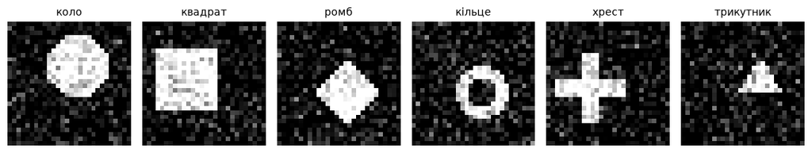

```
шість класів, по 200 прикладів кожного в запасі
```

```python
import matplotlib.pyplot as plt

figure, axes = plt.subplots(1, 6, figsize=(11, 2))
for kind in range(6):
    # перші шість зображень датасету — саме по одному на кожен клас
    axes[kind].imshow(pool_x[kind, 0], cmap="gray")
    axes[kind].set_title(SHAPE_NAMES[kind], fontsize=10)
    axes[kind].axis("off")
plt.tight_layout()
plt.show()
print("шість класів, по", len(pool_y) // 6, "прикладів кожного в запасі")
```

## 2 · Наше дзеркало проти бібліотечного

Перше правило курсу: перш ніж користуватись бібліотекою, зроби те саме руками й звір. Дзеркало по горизонталі — це просто перестановка стовпців у зворотному порядку, тобто зріз `[..., ::-1]`. Порівняємо з `v2.functional.horizontal_flip` і вимагатимемо **точного** збігу, а не приблизного: перестановка не втрачає жодного біта.

```python
def flip_horizontal_by_hand(images):
    """Дзеркало по горизонталі: останній вимір (стовпці) у зворотному порядку."""
    as_numpy = images.numpy()
    # ::-1 дає «вид» із відʼємним кроком, а torch такого не приймає — робимо копію
    flipped = np.ascontiguousarray(as_numpy[..., ::-1])
    return torch.from_numpy(flipped)


our_flip = flip_horizontal_by_hand(pool_x[:64])
library_flip = v2.functional.horizontal_flip(pool_x[:64])

assert torch.equal(our_flip, library_flip), "дзеркало розійшлося з бібліотечним!"
print("✅ збігається точно, до останнього біта")
print("максимальна різниця:", (our_flip - library_flip).abs().max().item())
```

```
✅ збігається точно, до останнього біта
максимальна різниця: 0.0
```

Друге порівняння — складніше й тому цікавіше. Зсув на ціле число пікселів теж можна написати руками: беремо `np.roll` і зануляємо те, що «заїхало» з протилежного краю. `torchvision` робить це через афінне перетворення, і при цілому зсуві та найближчому сусіді результат мусить збігтися.

```python
def shift_by_hand(images, dy, dx):
    """Зсув на ціле число пікселів; те, що виїхало за край, заміняємо нулями."""
    moved = torch.roll(images, shifts=(dy, dx), dims=(2, 3))
    # roll переносить пікселі по колу, а нам потрібен порожній край — зануляємо його
    if dy > 0:
        moved[:, :, :dy, :] = 0
    elif dy < 0:
        moved[:, :, dy:, :] = 0
    if dx > 0:
        moved[:, :, :, :dx] = 0
    elif dx < 0:
        moved[:, :, :, dx:] = 0
    return moved


our_shift = shift_by_hand(pool_x[:64], dy=3, dx=-2)
library_shift = v2.functional.affine(
    pool_x[:64], angle=0.0, translate=[-2, 3], scale=1.0, shear=[0.0, 0.0],
    interpolation=v2.InterpolationMode.NEAREST)

print("однакових пікселів: %.4f" % torch.isclose(our_shift, library_shift).float().mean().item())
assert torch.allclose(our_shift, library_shift), "зсув розійшовся з бібліотечним!"
print("✅ збігається: np.allclose пройшов")
```

```
однакових пікселів: 1.0000
✅ збігається: np.allclose пройшов
```

## 3 · Яке перетворення зберігає мітку — геометрією, без навчання

Тепер найважливіший інструмент теми. Щоб перевірити твердження «`y(T(x)) = y(x)`», навчати мережу не потрібно: досить порівняти перетворену фігуру з еталонними шаблонами всіх шести класів.

Три деталі, без яких вимірювання було б неправильним:

- **центруємо за центром мас** — інакше «зсув зламав мітку» означало б лише, що фігура поїхала вбік;
- **шаблон свого класу беремо з найближчою площею** — інакше «масштаб зламав мітку» означало б лише, що фігура стала більшою;
- **малюємо на сітці 56×56** замість 28×28 — на грубому растрі поворот лишає зубці, і збіг падає через них, а не через форму.

Міра збігу — IoU: площа спільної частини, поділена на площу обʼєднання.

```python
GRID = 56                      # удвічі дрібніша сітка: міряємо геометрію, а не зубці
CENTER = (GRID - 1) / 2
TEMPLATE_RADII = [8, 10, 12, 14, 16, 18, 20]
BASE_RADIUS = 14               # радіус фігури, з якою працюємо в цьому розділі


def shape_mask(kind, radius, size=GRID):
    """Та сама формула, що й у датасеті, але без шуму й на заданій сітці."""
    yy, xx = np.mgrid[0:size, 0:size]
    dy, dx = yy - (size - 1) / 2, xx - (size - 1) / 2
    if kind == 0:
        mask = dy * dy + dx * dx <= radius * radius
    elif kind == 1:
        mask = (np.abs(dy) <= radius * 0.85) & (np.abs(dx) <= radius * 0.85)
    elif kind == 2:
        mask = np.abs(dy) + np.abs(dx) <= radius
    elif kind == 3:
        distance = dy * dy + dx * dx
        mask = (distance <= radius * radius) & (distance >= (radius - 5.0) ** 2)
    elif kind == 4:
        mask = (((np.abs(dy) <= 3.0) & (np.abs(dx) <= radius))
                | ((np.abs(dx) <= 3.0) & (np.abs(dy) <= radius)))
    else:
        mask = ((dy >= -radius * 0.8) & (dy <= radius * 0.8)
                & (np.abs(dx) <= (dy + radius * 0.8) * 0.6))
    return mask


def warp(mask, degrees=0.0, shift_y=0.0, shift_x=0.0, scale=1.0, flip=False):
    """Поворот, зсув, масштаб і дзеркало зворотним відображенням, найближчий сусід."""
    angle = np.deg2rad(degrees)
    cos_a, sin_a = np.cos(angle), np.sin(angle)
    yy, xx = np.mgrid[0:GRID, 0:GRID]
    dy = (yy - CENTER - shift_y) / scale
    dx = (xx - CENTER - shift_x) / scale
    source_y = dy * cos_a - dx * sin_a
    source_x = dy * sin_a + dx * cos_a
    if flip:
        source_x = -source_x
    source_y = np.rint(source_y + CENTER).astype(int)
    source_x = np.rint(source_x + CENTER).astype(int)
    inside = ((source_y >= 0) & (source_y < GRID) & (source_x >= 0) & (source_x < GRID))
    out = np.zeros((GRID, GRID), dtype=bool)
    out[inside] = mask[source_y[inside], source_x[inside]]
    return out


def center_by_mass(mask):
    """Зсуває фігуру так, щоб її центр мас опинився в центрі кадру."""
    if not mask.any():
        return mask
    ys, xs = np.nonzero(mask)
    shift_y = int(round(CENTER - ys.mean()))
    shift_x = int(round(CENTER - xs.mean()))
    out = np.zeros_like(mask)
    new_y, new_x = ys + shift_y, xs + shift_x
    keep = (new_y >= 0) & (new_y < GRID) & (new_x >= 0) & (new_x < GRID)
    out[new_y[keep], new_x[keep]] = True
    return out


def iou(a, b):
    """Площа перетину, поділена на площу обʼєднання."""
    union = np.logical_or(a, b).sum()
    return 0.0 if union == 0 else float(np.logical_and(a, b).sum()) / union


TEMPLATES = {kind: [(center_by_mass(shape_mask(kind, r)), int(shape_mask(kind, r).sum()))
                    for r in TEMPLATE_RADII]
             for kind in range(6)}


def score_for(centered, area, kind):
    """Збіг із шаблоном свого класу, найближчим за площею."""
    template, _ = min(TEMPLATES[kind], key=lambda pair: abs(pair[1] - area))
    return iou(centered, template)


def nearest_class(mask):
    """Клас, на який перетворена фігура тепер схожа найбільше, і сам збіг."""
    centered = center_by_mass(mask)
    area = int(centered.sum())
    scores = [score_for(centered, area, kind) for kind in range(6)]
    best = int(np.argmax(scores))
    return best, scores[best]


# перевірка самого інструмента: неперетворена фігура мусить впізнаватись ідеально
for kind in range(6):
    got, score = nearest_class(shape_mask(kind, BASE_RADIUS))
    assert got == kind and score > 0.99, "класифікатор шаблонів зламаний на %s" % SHAPE_NAMES[kind]
print("✅ шаблонний класифікатор упізнає всі шість класів зі збігом 1.000")
```

```
✅ шаблонний класифікатор упізнає всі шість класів зі збігом 1.000
```

Інструмент працює. Тепер поставимо йому три питання, які й вирішують, що можна класти в конвеєр аугментації, а що ні.

```python
print("%-11s %-22s %-22s %s" % ("клас", "дзеркало", "зсув на 8", "поворот на 45°"))
print("-" * 78)
for kind in range(6):
    base = shape_mask(kind, BASE_RADIUS)
    results = []
    for transformed in (warp(base, flip=True),
                        warp(base, shift_y=8, shift_x=-6),
                        warp(base, degrees=45)):
        got, score = nearest_class(transformed)
        mark = " " if got == kind else "!"
        results.append("%-10s %.3f%s" % (SHAPE_NAMES[got], score, mark))
    print("%-11s %-22s %-22s %s" % (SHAPE_NAMES[kind], results[0], results[1], results[2]))
print()
print("знак ! означає, що мітка змінилася — такий приклад пішов би в навчання з брехнею")
```

```
клас        дзеркало               зсув на 8              поворот на 45°
------------------------------------------------------------------------------
```

```
коло        коло       1.000       коло       1.000       коло       0.987
квадрат     квадрат    1.000       квадрат    1.000       ромб       1.000!
ромб        ромб       1.000       ромб       1.000       квадрат    0.980!
кільце      кільце     1.000       кільце     1.000       кільце     0.978
хрест       хрест      1.000       хрест      1.000       квадрат    0.622!
```

```
трикутник   трикутник  1.000       трикутник  1.000       квадрат    0.689!

знак ! означає, що мітка змінилася — такий приклад пішов би в навчання з брехнею
```

Дзеркало й зсув не змінили жодної мітки. Поворот на 45° змінив чотири з шести — і найяскравіше на квадраті: він **точно** перетворився на ромб.

Тепер знайдемо, з якого кута мітка ламається для кожного класу. Це число і є межею безпечної сили повороту в цьому датасеті.

```python
print("%-11s %s" % ("клас", "найменший кут, на якому мітка вже не та"))
print("-" * 52)
break_angles = {}
for kind in range(6):
    base = shape_mask(kind, BASE_RADIUS)
    first_bad = None
    for degrees in range(0, 91):
        if nearest_class(warp(base, degrees=degrees))[0] != kind:
            first_bad = degrees
            break
    break_angles[kind] = first_bad
    print("%-11s %s" % (SHAPE_NAMES[kind], first_bad if first_bad is not None else "не ламається до 90°"))

# частка збережених міток, якщо кут беруть випадково з відрізка [-a, a]
keeps = np.zeros((6, 61), dtype=bool)
for kind in range(6):
    base = shape_mask(kind, BASE_RADIUS)
    for degrees in range(61):
        keeps[kind, degrees] = nearest_class(warp(base, degrees=degrees))[0] == kind

print()
print("максимальний кут → частка прикладів, де мітка вціліла")
for limit in (5, 8, 10, 15, 20, 30, 45, 60):
    print("   до %2d° : %.3f" % (limit, keeps[:, :limit + 1].mean()))
```

```
клас        найменший кут, на якому мітка вже не та
----------------------------------------------------
```

```
коло        не ламається до 90°
квадрат     16
```

```
ромб        13
```

```
кільце      не ламається до 90°
```

```
хрест       17
трикутник   17
```

```
максимальний кут → частка прикладів, де мітка вціліла
   до  5° : 1.000
   до  8° : 1.000
   до 10° : 1.000
   до 15° : 0.979
   до 20° : 0.841
   до 30° : 0.677
   до 45° : 0.565
   до 60° : 0.508
```

Ось і відповідь, ще до першого навчання: **поворот до 10° у цьому датасеті безпечний, а поворот до 45° псує майже половину прикладів**. Далі перевіримо, чи погодиться з цим мережа.

## 4 · Мережа й функція навчання

Мережа — та сама, що в темі 09: три блоки `Conv → ReLU → Pool` і голова з `Flatten`. Нового тут лише одне: у навчальному циклі перед подачею в мережу батч проходить через `transform`, якщо він заданий.

Важлива деталь про бюджет: усі досліди роблять **однакову кількість кроків** (250), а не однакову кількість епох. Інакше мережа на 120 прикладах отримала б у десять разів менше оновлень ваг, ніж на 1200, і ми порівнювали б не кількість даних, а кількість обчислень.

```python
STEPS = 250          # однаковий бюджет навчання для всіх дослідів
BATCH = 32
CHECK_EVERY = 25     # як часто міряти точність


def conv_block(in_channels, out_channels):
    """Один типовий блок із теми 09: Conv → ReLU → Pool."""
    return nn.Sequential(
        nn.Conv2d(in_channels, out_channels, kernel_size=3, padding=1),
        nn.ReLU(),
        nn.MaxPool2d(2),
    )


class ShapeNet(nn.Module):
    """Три блоки з подвоєнням каналів і голова з Flatten. 24 774 параметри."""

    def __init__(self):
        super().__init__()
        self.body = nn.Sequential(conv_block(1, 8), conv_block(8, 16), conv_block(16, 32))
        self.head = nn.Sequential(
            nn.Flatten(), nn.Linear(32 * 3 * 3, 64), nn.ReLU(), nn.Linear(64, 6))

    def forward(self, x):
        return self.head(self.body(x))


def accuracy(model, images, labels):
    """Частка правильних відповідей; градієнти тут не потрібні, тому no_grad."""
    model.eval()
    with torch.no_grad():
        parts = [model(images[s:s + 300]).argmax(dim=1) for s in range(0, len(images), 300)]
    model.train()
    return round((torch.cat(parts) == labels).float().mean().item(), 4)


def train_model(train_x, train_y, transform=None, steps=STEPS, seed=0):
    """Навчає мережу з нуля. Повертає модель, історію точності й витрачений час."""
    torch.manual_seed(seed)                       # без зерна числа не повторяться
    model = ShapeNet()
    optimizer = torch.optim.Adam(model.parameters(), lr=3e-3)
    loss_function = nn.CrossEntropyLoss()
    history = []
    started = time.time()

    order = torch.randperm(len(train_x))
    position = 0
    for step in range(1, steps + 1):
        if position + BATCH > len(train_x):       # вибірка скінчилась — перемішуємо знову
            order = torch.randperm(len(train_x))
            position = 0
        batch_index = order[position:position + BATCH]
        position += BATCH

        batch_images = train_x[batch_index]
        if transform is not None:
            # аугментація на льоту: щоразу нові випадкові параметри
            batch_images = transform(batch_images)

        optimizer.zero_grad()
        loss_function(model(batch_images), train_y[batch_index]).backward()
        optimizer.step()

        if step % CHECK_EVERY == 0:
            history.append((step,
                            accuracy(model, train_x, train_y),
                            accuracy(model, test_x, test_y)))
    return model, history, round(time.time() - started, 1)


print("параметрів у мережі:", sum(p.numel() for p in ShapeNet().parameters()))
```

```
параметрів у мережі: 24774
```

Конвеєр аугментації описується одним `Compose`. Різні досліди відрізнятимуться **рівно одним числом** — максимальним кутом повороту.

```python
def augmentation(max_degrees):
    """Дзеркало, поворот, зсув і масштаб. Міняється тільки кут."""
    return v2.Compose([
        v2.RandomHorizontalFlip(p=0.5),
        v2.RandomAffine(degrees=max_degrees, translate=(0.2, 0.2), scale=(0.85, 1.15)),
    ])


# перевіримо відтворюваність: із тим самим зерном перетворення дає той самий результат
torch.manual_seed(123)
first_run = augmentation(8)(pool_x[:8])
torch.manual_seed(123)
second_run = augmentation(8)(pool_x[:8])
assert torch.equal(first_run, second_run), "аугментація не відтворюється!"
print("✅ з тим самим torch.manual_seed аугментація дає той самий результат")
```

```
✅ з тим самим torch.manual_seed аугментація дає той самий результат
```

## 5 · Замір 1: виграш на малій вибірці

Беремо 120 навчальних зображень (по 20 на клас) і навчаємо дві мережі: без аугментації та з аугментацією, у якій поворот обмежено 8° — тим самим кутом, який геометрія щойно визнала безпечним. Усе решта однакове, включно з зерном.

**Це перші два навчання з восьми; разом вони займають десятки секунд.**

```python
results = {}          # сюди складаємо всі досліди зошита

model, history, seconds = train_model(pool_x[:120], pool_y[:120], None)
results["без аугментації, 120"] = history
print("без аугментації, 120: %5.1f с  на навчальній %.3f  на перевірочній %.3f"
      % (seconds, history[-1][1], history[-1][2]))

model, history, seconds = train_model(pool_x[:120], pool_y[:120], augmentation(8))
results["з аугментацією, 120"] = history
print("з аугментацією,  120: %5.1f с  на навчальній %.3f  на перевірочній %.3f"
      % (seconds, history[-1][1], history[-1][2]))
```

```
без аугментації, 120:   7.3 с  на навчальній 1.000  на перевірочній 0.880
```

```
з аугментацією,  120:   6.5 с  на навчальній 0.942  на перевірочній 0.965
```

Дивимось не на одне число, а на **розрив** між навчальною й перевірочною точністю. Саме він і є мірою запамʼятовування.

```python
without = results["без аугментації, 120"]
with_aug = results["з аугментацією, 120"]

print("%6s | %-24s | %s" % ("крок", "без аугментації", "з аугментацією"))
print("%6s | %7s %7s %7s | %7s %7s %7s"
      % ("", "навч.", "перев.", "розрив", "навч.", "перев.", "розрив"))
print("-" * 62)
for (step, a_train, a_test), (_, b_train, b_test) in zip(without, with_aug):
    print("%6d | %7.3f %7.3f %7.3f | %7.3f %7.3f %7.3f"
          % (step, a_train, a_test, a_train - a_test, b_train, b_test, b_train - b_test))

print()
print("наприкінці навчання розрив без аугментації %.3f, з нею %.3f"
      % (without[-1][1] - without[-1][2], with_aug[-1][1] - with_aug[-1][2]))
print("виграш на перевірочній вибірці: %+.3f" % (with_aug[-1][2] - without[-1][2]))
```

```
  крок | без аугментації          | з аугментацією
       |   навч.  перев.  розрив |   навч.  перев.  розрив
--------------------------------------------------------------
    25 |   0.408   0.353   0.055 |   0.267   0.267   0.000
    50 |   0.617   0.547   0.070 |   0.500   0.507  -0.007
    75 |   0.892   0.807   0.085 |   0.558   0.540   0.018
   100 |   1.000   0.868   0.132 |   0.758   0.710   0.048
   125 |   1.000   0.860   0.140 |   0.633   0.617   0.017
   150 |   1.000   0.880   0.120 |   0.917   0.928  -0.012
   175 |   1.000   0.878   0.122 |   0.850   0.865  -0.015
   200 |   1.000   0.880   0.120 |   0.958   0.975  -0.017
   225 |   1.000   0.880   0.120 |   0.950   0.952  -0.002
   250 |   1.000   0.880   0.120 |   0.942   0.965  -0.023

наприкінці навчання розрив без аугментації 0.120, з нею -0.023
виграш на перевірочній вибірці: +0.085
```

## 6 · Замір 3: коли аугментація шкодить

Тепер шкідливий випадок. Беремо той самий конвеєр і той самий набір із 120 зображень, міняємо **одне число** — максимальний кут повороту: 8° → 20° → 45°. Геометрія вже сказала, чого чекати; подивимось, чи мережа з нею погодиться.

```python
for max_degrees in (20, 45):
    model, history, seconds = train_model(pool_x[:120], pool_y[:120], augmentation(max_degrees))
    results["поворот до %d°, 120" % max_degrees] = history
    print("поворот до %2d°: %5.1f с  на навчальній %.3f  на перевірочній %.3f"
          % (max_degrees, seconds, history[-1][1], history[-1][2]))
```

```
поворот до 20°:   6.1 с  на навчальній 0.958  на перевірочній 0.982
```

```
поворот до 45°:   5.3 с  на навчальній 0.692  на перевірочній 0.688
```

```python
print("%-18s %10s %11s %11s %13s"
      % ("аугментація", "мітка ціла", "навчальна", "перевірочна", "проти базової"))
print("-" * 68)
base_accuracy = results["без аугментації, 120"][-1][2]
rows = [("немає", 0, results["без аугментації, 120"][-1]),
        ("поворот до 8°", 8, results["з аугментацією, 120"][-1]),
        ("поворот до 20°", 20, results["поворот до 20°, 120"][-1]),
        ("поворот до 45°", 45, results["поворот до 45°, 120"][-1])]
for name, limit, last in rows:
    survived = keeps[:, :limit + 1].mean()
    print("%-18s %9.0f%% %11.3f %11.3f %+13.3f"
          % (name, survived * 100, last[1], last[2], last[2] - base_accuracy))
```

```
аугментація        мітка ціла   навчальна перевірочна проти базової
--------------------------------------------------------------------
немає                    100%       1.000       0.880        +0.000
поворот до 8°            100%       0.942       0.965        +0.085
поворот до 20°            84%       0.958       0.982        +0.102
поворот до 45°            57%       0.692       0.688        -0.192
```

Числа виявились не такими простими, як обіцяла геометрія, і це найцінніше місце теми. Поворот до 8°, де мітку зберігають **усі** приклади, допоміг. Поворот до 20°, де мітку зберігають лише 84 %, допоміг **ще більше**. І тільки поворот до 45°, де брехнею стає майже половина прикладів, виявився гіршим за повну відсутність аугментації.

Висновок: геометричний рахунок — це **попередження, а не заборона**. Він каже, скільки прикладів стануть брехливими, але не каже, чи буде від цього шкода: трохи зіпсованих міток мережа витримує, якщо взамін бачить більше різних картинок. Силу добирають замірами, а геометрію використовують, щоб знати, де взагалі є сенс шукати.

## 7 · Замір 2: чи лишається виграш, коли даних більше

Повторюємо перший дослід на 360 і на 1200 прикладах. Бюджет навчання той самий — 250 кроків, — тож єдине, що змінюється, це кількість **різних** зображень, які бачить мережа.

**Це чотири навчання — приблизно половина всього часу зошита.**

```python
models = {}           # знадобляться в замірі 4

for count in (360, 1200):
    model, history, seconds = train_model(pool_x[:count], pool_y[:count], None)
    results["без аугментації, %d" % count] = history
    models["без аугментації, %d" % count] = model
    print("без аугментації, %4d: %5.1f с  на навчальній %.3f  на перевірочній %.3f"
          % (count, seconds, history[-1][1], history[-1][2]))

    model, history, seconds = train_model(pool_x[:count], pool_y[:count], augmentation(8))
    results["з аугментацією, %d" % count] = history
    models["з аугментацією, %d" % count] = model
    print("з аугментацією,  %4d: %5.1f с  на навчальній %.3f  на перевірочній %.3f"
          % (count, seconds, history[-1][1], history[-1][2]))
```

```
без аугментації,  360:   6.4 с  на навчальній 1.000  на перевірочній 0.972
```

```
з аугментацією,   360:   7.6 с  на навчальній 0.986  на перевірочній 0.985
```

```
без аугментації, 1200:   9.5 с  на навчальній 1.000  на перевірочній 0.990
```

```
з аугментацією,  1200:   7.7 с  на навчальній 0.960  на перевірочній 0.970
```

```python
print("%10s %14s %14s %10s" % ("навчальних", "без аугментації", "з аугментацією", "виграш"))
print("-" * 52)
for count in (120, 360, 1200):
    without_value = results["без аугментації, %d" % count][-1][2]
    with_value = results["з аугментацією, %d" % count][-1][2]
    print("%10d %14.3f %14.3f %+10.3f" % (count, without_value, with_value, with_value - without_value))
```

```
навчальних без аугментації з аугментацією     виграш
----------------------------------------------------
       120          0.880          0.965     +0.085
       360          0.972          0.985     +0.013
      1200          0.990          0.970     -0.020
```

Виграш падає зі зростанням вибірки. Причину видно в колонці «на навчальній» попередніх дослідів: з аугментацією мережа за ті самі 250 кроків встигає вивчити менше, бо задача складніша. Коли даних мало, ця ціна окупається з надлишком; коли даних досить — окупати вже нема чого.

Осторога до цього заміру: бюджет навчання тут фіксований. Якби ми вчили довше, картина на найбільшій вибірці могла б змінитись. Висновок точний саме в постановці «однакова кількість обчислень» — тій, у якій опиняється більшість практичних задач.

## 8 · Замір 4: що буде, якщо аугментувати перевірочну вибірку

Візьмемо дві моделі, які на чистій перевірочній вибірці показують майже однакову якість: одна навчена на 1200 прикладах **без** аугментації, друга — на 360 **з** аугментацією. На чистій вибірці кожна дає одне число, і друге вимірювання дасть те саме.

Тепер поміряємо їх вісім разів на **аугментованій** перевірочній вибірці, міняючи лише зерно. Дивимось на дві речі: наскільки стрибає число в кожної моделі й чи міняється відповідь на питання «яка модель краща».

```python
model_a = models["без аугментації, 1200"]     # модель А: багато даних, без аугментації
model_b = models["з аугментацією, 360"]       # модель Б: утричі менше даних, але з нею

clean_a = accuracy(model_a, test_x, test_y)
clean_b = accuracy(model_b, test_x, test_y)
print("на чистій перевірочній: А %.3f, Б %.3f" % (clean_a, clean_b))
print("різниця між моделями: %.3f — і вона повторювана" % abs(clean_a - clean_b))
print()

test_transform = augmentation(8)
runs_a, runs_b = [], []
for seed in range(8):
    torch.manual_seed(1000 + seed)
    # аугментуємо перевірочну вибірку так само, як навчальну — саме цього робити не можна
    noisy_test = torch.cat([test_transform(test_x[s:s + 64]) for s in range(0, len(test_x), 64)])
    runs_a.append(accuracy(model_a, noisy_test, test_y))
    runs_b.append(accuracy(model_b, noisy_test, test_y))
    print("зерно %4d: А → %.3f   Б → %.3f   краща: %s"
          % (1000 + seed, runs_a[-1], runs_b[-1],
             "А" if runs_a[-1] > runs_b[-1] else ("Б" if runs_b[-1] > runs_a[-1] else "нічия")))
```

```
на чистій перевірочній: А 0.990, Б 0.985
різниця між моделями: 0.005 — і вона повторювана
```

```
зерно 1000: А → 0.828   Б → 0.938   краща: Б
```

```
зерно 1001: А → 0.798   Б → 0.915   краща: Б
```

```
зерно 1002: А → 0.795   Б → 0.925   краща: Б
```

```
зерно 1003: А → 0.830   Б → 0.935   краща: Б
```

```
зерно 1004: А → 0.745   Б → 0.902   краща: Б
```

```
зерно 1005: А → 0.760   Б → 0.922   краща: Б
```

```
зерно 1006: А → 0.775   Б → 0.920   краща: Б
```

```
зерно 1007: А → 0.762   Б → 0.907   краща: Б
```

```python
spread_a = max(runs_a) - min(runs_a)
spread_b = max(runs_b) - min(runs_b)
wins_a = sum(1 for a, b in zip(runs_a, runs_b) if a > b)
wins_b = sum(1 for a, b in zip(runs_a, runs_b) if b > a)

print("розкид від зерна: у моделі А — %.3f, у моделі Б — %.3f" % (spread_a, spread_b))
print("різниця між моделями на чистій вибірці: %.3f" % abs(clean_a - clean_b))
print("на аугментованій «кращою» була А в %d прогонах із 8, Б — у %d" % (wins_a, wins_b))
print()
print("середнє на аугментованій: А %.3f, Б %.3f"
      % (sum(runs_a) / len(runs_a), sum(runs_b) / len(runs_b)))
print("тобто зміна способу перевірки посунула відповідь на %.3f — більше, ніж уся"
      % abs((sum(runs_a) / len(runs_a)) - (sum(runs_b) / len(runs_b))))
print("різниця між моделями на чистій вибірці (%.3f)" % abs(clean_a - clean_b))
```

```
розкид від зерна: у моделі А — 0.085, у моделі Б — 0.037
різниця між моделями на чистій вибірці: 0.005
на аугментованій «кращою» була А в 0 прогонах із 8, Б — у 8

середнє на аугментованій: А 0.787, Б 0.920
тобто зміна способу перевірки посунула відповідь на 0.134 — більше, ніж уся
різниця між моделями на чистій вибірці (0.005)
```

Два висновки, і другий важливіший за перший.

**Перший:** число на аугментованій перевірці плаває. Модель не змінилась, вибірка не змінилась — змінилось лише зерно, а точність інша. Публікувати таке число як «точність моделі» не можна.

**Другий:** аугментована перевірка не нейтральна. Вона міняє відповідь на питання «яка модель краща» — а моделі при цьому ті самі, що й були. Тобто ти більше не порівнюєш моделі, ти порівнюєш те, наскільки кожна з них дружить із твоїм конвеєром перетворень.

## 9 · TTA: аугментація на прогнозі — це інше

Помилка з розділу 8 полягала в тому, що випадковий варіант **заміняв** оригінал. TTA робить протилежне: проганяє кілька варіантів і **усереднює** прогнози. Результат детермінований, а ціна пряма — стільки прогонів мережі, скільки варіантів.

Але є умова, про яку легко забути: TTA допомагає лише тоді, коли модель **терпить** ці перетворення. Перевіримо на обох моделях із попереднього розділу — на тій, що навчалась без аугментації, і на тій, що з нею.

```python
def predict_with_tta(model, variants=4):
    """Усереднює ймовірності по оригіналу й кількох аугментованих варіантах."""
    torch.manual_seed(7)                      # набір варіантів має бути відтворюваним
    with torch.no_grad():
        # перший доданок — сам оригінал, далі аугментовані варіанти
        total_probabilities = torch.softmax(model(test_x), dim=1)
        for variant in range(variants):
            noisy_test = torch.cat([test_transform(test_x[s:s + 64])
                                    for s in range(0, len(test_x), 64)])
            total_probabilities = total_probabilities + torch.softmax(model(noisy_test), dim=1)
    return round((total_probabilities.argmax(dim=1) == test_y).float().mean().item(), 4)


started = time.time()
print("%-34s %10s %10s %8s" % ("модель", "звичайно", "з TTA", "різниця"))
print("-" * 66)
for name, model, clean_value in (("А · 1200 без аугментації", model_a, clean_a),
                                 ("Б · 360 з аугментацією", model_b, clean_b)):
    tta_value = predict_with_tta(model)
    print("%-34s %10.3f %10.3f %+8.3f" % (name, clean_value, tta_value, tta_value - clean_value))
print()
print("ціна в обох випадках однакова: пʼять прогонів мережі замість одного")
print("час на обидва TTA: %.1f с" % (time.time() - started))
```

```
модель                               звичайно      з TTA  різниця
------------------------------------------------------------------
```

```
А · 1200 без аугментації                0.990      0.958   -0.032
```

```
Б · 360 з аугментацією                  0.985      0.990   +0.005

ціна в обох випадках однакова: пʼять прогонів мережі замість одного
час на обидва TTA: 1.9 с
```

## 10 · Завдання

### 🟢 Рівень 1

Повтори замір 1, замінивши афінне перетворення на `v2.RandomResizedCrop(28, scale=(0.6, 1.0), antialias=True)`. Спершу поміряй геометрією, з якого `scale` мітки починають ламатись, і лише потім навчай.

### 🟡 Рівень 2

Перебором по частці площі знайди, з якої частки `RandomErasing` ламає **кільце** — і перевір це навчанням: дві мережі, з безпечним стиранням і з руйнівним.

### 🔴 Рівень 3

Зроби власний датасет зі стрілками (вгору, вниз, ліворуч, праворуч і дві подвійні), підбери під нього набір перетворень і **доведи числом**, що кожне з них зберігає мітку.

Повний текст завдань із критеріями «зроблено» — у homework.html.